# Daily_Website_Visitors

### Time Series Analysis - Time_Series_Analysis_Daily_Website_Visitors

Introduction to Time-Series Analysis  
• A time-series data is a series of data points or observations recorded at different or regular time intervals. In general, a time series is a sequence of data points taken at equally spaced time intervals. The frequency of recorded data points may be hourly, daily, weekly, monthly, quarterly or annually.  
• Time-Series Forecasting is the process of using a statistical model to predict future values of a time-series based on past results. • A time series analysis encompasses statistical methods for analyzing time series data. These methods enable us to extract meaningful statistics, patterns and other characteristics of the data. Time series are visualized with the help of line charts. So, time series analysis involves understanding inherent aspects of the time series data so that we can create meaningful and accurate forecasts.  
• Applications of time series are used in statistics, finance or business applications. A very common example of time series data is the daily closing value of the stock index like NASDAQ or Dow Jones. Other common applications of time series are sales and demand forecasting, weather forecasting, econometrics, signal processing, pattern recognition and earthquake prediction

### Components of a Time-Series

• Trend - The trend shows a general direction of the time series data over a long period of time. A trend can be increasing(upward), decreasing(downward), or horizontal(stationary).  
• Seasonality - The seasonality component exhibits a trend that repeats with respect to timing, direction, and magnitude. Some examples include an increase in water consumption in summer due to hot weather conditions.  
• Cyclical Component - These are the trends with no set repetition over a particular period of time. A cycle refers to the period of ups and downs, booms and slums of a time series, mostly observed in business cycles. These cycles do not exhibit a seasonal variation but generally occur over a time period of 3 to 12 years depending on the nature of the time series.  
• Irregular Variation - These are the fluctuations in the time series data which become evident when trend and cyclical variations are removed. These variations are unpredictable, erratic, and may or may not be random.  
• ETS Decomposition - ETS Decomposition is used to separate different components of a time series. The term ETS stands for Error, Trend and Seasonality

```python
##!mkdir ~/.kaggle
```

```python
##!cp /kaggle.json ~/.kaggle/
```

```python
##!chmod 600 ~/.kaggle/kaggle.json
```

```python
####! pip install kaggle
```

```python
####!pip install keras-tuner
```

```python
###! kaggle datasets download -d bobnau/daily-website-visitors
```

```python
###! unzip ./daily-website-visitors.zip
```

```python
###! pip install tensorflow
```

```python
import pandas as pd
import numpy as np
import tensorflow as tf
from sklearn import preprocessing
import matplotlib.pyplot as plt
tf.random.set_seed(123)
np.random.seed(123)
```

```python
import pandas as pd
#import fbprophet
import matplotlib.pyplot as plt
%matplotlib inline
import numpy as np
```

```python
df=pd.read_csv('/content/daily-website-visitors.csv', parse_dates=['Date'], index_col ="Date")
df.head(3)
```

| Date | Row | Day | Day.Of.Week | Page.Loads | Unique.Visits | First.Time.Visits | Returning.Visits |
| --- | --- | --- | --- | --- | --- | --- | --- |
| 2014-09-14 | 1 | Sunday | 1 | 2,146 | 1,582 | 1,430 | 152 |
| 2014-09-15 | 2 | Monday | 2 | 3,621 | 2,528 | 2,297 | 231 |
| 2014-09-16 | 3 | Tuesday | 3 | 3,698 | 2,630 | 2,352 | 278 |

```python
df.columns
```

```
Index(['Row', 'Day', 'Day.Of.Week', 'Page.Loads', 'Unique.Visits',
       'First.Time.Visits', 'Returning.Visits'],
      dtype='object')
```

```python
df2 = df [['Page.Loads', 'Unique.Visits',
       'First.Time.Visits', 'Returning.Visits']]
```

```python
df2.describe()
```

|  | Page.Loads | Unique.Visits | First.Time.Visits | Returning.Visits |
| --- | --- | --- | --- | --- |
| count | 2167 | 2167 | 2167 | 2167 |
| unique | 1756 | 1658 | 1587 | 663 |
| top | 2,948 | 2,780 | 3,146 | 552 |
| freq | 5 | 5 | 5 | 12 |

```python
df2['Page.Loads'] = df2['Page.Loads'].str.replace(',', '').astype(int)
```

```python
df2['Unique.Visits'] = df2['Unique.Visits'].str.replace(',', '').astype(int)
```

```python
df2['First.Time.Visits'] = df2['First.Time.Visits'].str.replace(',', '').astype(int)
```

```python
df2['Returning.Visits'] = df2['Returning.Visits'].str.replace(',', '').astype(int)
```

```python
df2.head(3)
```

| Date | Page.Loads | Unique.Visits | First.Time.Visits | Returning.Visits |
| --- | --- | --- | --- | --- |
| 2014-09-14 | 2146 | 1582 | 1430 | 152 |
| 2014-09-15 | 3621 | 2528 | 2297 | 231 |
| 2014-09-16 | 3698 | 2630 | 2352 | 278 |

```python
# Basic packages
import numpy as np # linear algebra
import pandas as pd # data processing, CSV file I/O (e.g. pd.read_csv)
import random as rd # generating random numbers
import datetime # manipulating date formats
# Viz
import matplotlib.pyplot as plt # basic plotting
import seaborn as sns # for prettier plots
# TIME SERIES
from statsmodels.tsa.arima_model import ARIMA
from statsmodels.tsa.statespace.sarimax import SARIMAX
from pandas.plotting import autocorrelation_plot
from statsmodels.tsa.stattools import adfuller, acf, pacf,arma_order_select_ic
import statsmodels.formula.api as smf
import statsmodels.tsa.api as smt
import statsmodels.api as sm
import scipy.stats as scs
# settings
import warnings
warnings.filterwarnings("ignore")
```

```python
monthly_page_loads = df2["Page.Loads"].resample('M').sum()
```

```python
monthly_unique_visitors = df2["Unique.Visits"].resample('M').sum()
```

```python
monthly_First_Time_Visits = df2["First.Time.Visits"].resample('M').sum()
```

```python
monthly_Returning_Visits = df2["Returning.Visits"].resample('M').sum()
```

```python
monthly_page_loads.head(3)
```

```
Date
2014-09-30     56052
2014-10-31    121983
2014-11-30    114190
Freq: M, Name: Page.Loads, dtype: int64
```

```python
monthly_page_loads = pd.DataFrame(monthly_page_loads)
```

```python
monthly_page_loads.head(2)
```

| Date | Page.Loads |
| --- | --- |
| 2014-09-30 | 56052 |
| 2014-10-31 | 121983 |

```python
monthly_page_loads = monthly_page_loads.reset_index()
```

```python
monthly_page_loads['weekday'] = monthly_page_loads['Date'].apply(lambda x: x.weekday())
monthly_page_loads.head()
```

|  | Date | Page.Loads | weekday |
| --- | --- | --- | --- |
| 0 | 2014-09-30 | 56052 | 1 |
| 1 | 2014-10-31 | 121983 | 4 |
| 2 | 2014-11-30 | 114190 | 6 |
| 3 | 2014-12-31 | 105617 | 2 |
| 4 | 2015-01-31 | 96077 | 5 |

```python
monthly_page_loads['month']=monthly_page_loads['Date'].dt.month
monthly_page_loads.head()
```

|  | Date | Page.Loads | weekday | month |
| --- | --- | --- | --- | --- |
| 0 | 2014-09-30 | 56052 | 1 | 9 |
| 1 | 2014-10-31 | 121983 | 4 | 10 |
| 2 | 2014-11-30 | 114190 | 6 | 11 |
| 3 | 2014-12-31 | 105617 | 2 | 12 |
| 4 | 2015-01-31 | 96077 | 5 | 1 |

```python
monthly_page_loads['day']=monthly_page_loads['Date'].dt.day
monthly_page_loads.head()
```

|  | Date | Page.Loads | weekday | month | day |
| --- | --- | --- | --- | --- | --- |
| 0 | 2014-09-30 | 56052 | 1 | 9 | 30 |
| 1 | 2014-10-31 | 121983 | 4 | 10 | 31 |
| 2 | 2014-11-30 | 114190 | 6 | 11 | 30 |
| 3 | 2014-12-31 | 105617 | 2 | 12 | 31 |
| 4 | 2015-01-31 | 96077 | 5 | 1 | 31 |

```python
train_month = monthly_page_loads.groupby(["month", "weekday"])['Page.Loads'].mean().reset_index()
train_month = train_month.pivot('weekday','month','Page.Loads')
train_month.sort_index(inplace=True)
```

```python
train_month.head()
```

| month weekday | 1 | 2 | 3 | 4 | 5 | 6 | 7 | 8 | 9 | 10 | 11 | 12 |
| --- | --- | --- | --- | --- | --- | --- | --- | --- | --- | --- | --- | --- |
| 0 | NaN | 131171.0 | NaN | 175572.0 | NaN | NaN | 73308.0 | 79732.0 | 123213.0 | 157604.0 | 142650.0 | 139140.0 |
| 1 | 118114.0 | 122170.0 | 132481.5 | 167945.0 | 151279.0 | 119990.0 | 101669.0 | NaN | 56052.0 | 102451.0 | NaN | 124419.0 |
| 2 | 111716.0 | 121740.0 | NaN | NaN | 119004.0 | NaN | 103522.0 | 114891.0 | 114716.0 | 171488.0 | 159651.0 | 105617.0 |
| 3 | 129723.0 | 139744.0 | 145948.0 | 152386.5 | 161708.0 | 125190.0 | NaN | 72854.0 | NaN | 148176.0 | 112155.0 | 122397.0 |
| 4 | 106492.0 | NaN | 125290.0 | NaN | 140413.0 | 87766.0 | 104132.0 | 109901.0 | 126234.0 | 121983.0 | 167131.0 | NaN |

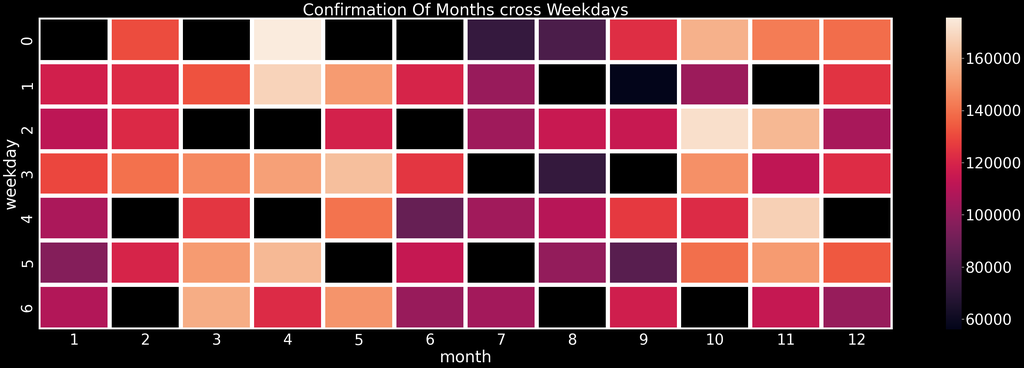

```python
import seaborn as sns


sns.set(font_scale=3.5)
plt.style.use('dark_background')
# Draw a heatmap with the numeric values in each cell
f, ax = plt.subplots(figsize=(50, 15))
sns.heatmap(train_month, annot=False, ax=ax, fmt="d", linewidths=10)
plt.title('Confirmation Of Months cross Weekdays')
plt.show()
```

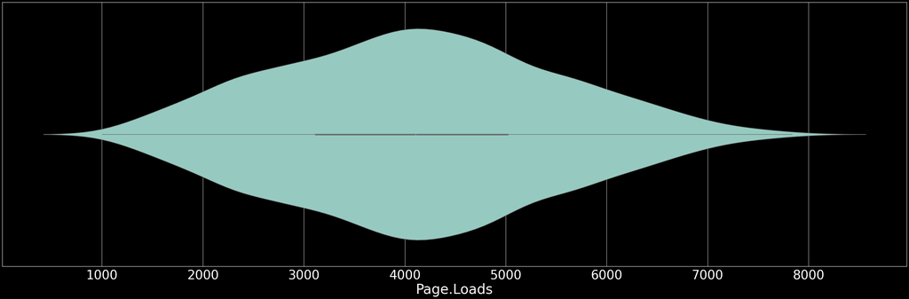

```python
plt.figure(figsize=(50,15))
plt.style.use('dark_background')
sns.violinplot(df2['Page.Loads'])
```

```python
monthly_page_loads.head(10)
```

|  | Date | Page.Loads | weekday | month | day |
| --- | --- | --- | --- | --- | --- |
| 0 | 2014-09-30 | 56052 | 1 | 9 | 30 |
| 1 | 2014-10-31 | 121983 | 4 | 10 | 31 |
| 2 | 2014-11-30 | 114190 | 6 | 11 | 30 |
| 3 | 2014-12-31 | 105617 | 2 | 12 | 31 |
| 4 | 2015-01-31 | 96077 | 5 | 1 | 31 |
| 5 | 2015-02-28 | 118876 | 5 | 2 | 28 |
| 6 | 2015-03-31 | 143990 | 1 | 3 | 31 |
| 7 | 2015-04-30 | 153331 | 3 | 4 | 30 |
| 8 | 2015-05-31 | 142113 | 6 | 5 | 31 |
| 9 | 2015-06-30 | 115297 | 1 | 6 | 30 |

```python
train_days = monthly_page_loads.groupby(["month", "day"])['Page.Loads'].mean().reset_index()
train_days = train_days.pivot('day','month','Page.Loads')
train_days.sort_index(inplace=True)
train_days.dropna(inplace=True)
```

```python
df2.columns
```

```
Index(['Page.Loads', 'Unique.Visits', 'First.Time.Visits', 'Returning.Visits'], dtype='object')
```

```python
import statsmodels.api as sm
from statsmodels.tsa.seasonal import seasonal_decompose
```

```python
#####! pip install plotly
```

```python
import plotly
# plotly.tools.set_credentials_file()
```

```python
monthly_page_loads.rename(columns = {"Page.Loads" : "Page_Loads"}, inplace=True)
```

```python
# Show Rolling mean, Rolling Std and Test for the stationnarity
df_date_index = monthly_page_loads[['Date','Page_Loads']].set_index('Date')
df_date_index.head()
```

| Date | Page_Loads |
| --- | --- |
| 2014-09-30 | 56052 |
| 2014-10-31 | 121983 |
| 2014-11-30 | 114190 |
| 2014-12-31 | 105617 |
| 2015-01-31 | 96077 |

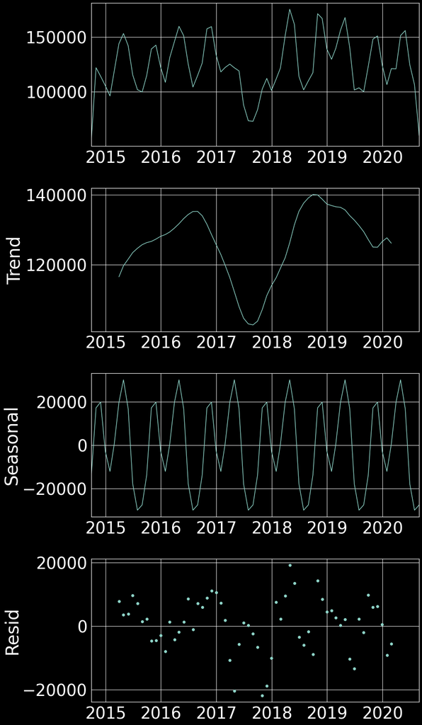

```python
from pylab import rcParams
rcParams['figure.figsize'] = 15, 25
decomposition = sm.tsa.seasonal_decompose(df_date_index, model='additive')
fig = decomposition.plot()
plt.show()
```

#### **Stationarity**

A Time Series is said to be stationary if its statistical properties such as mean, variance remain constant over time. Most of the Time Series models work on the assumption that the TS is stationary. Major reason for this is that there are many ways in which a series can be non-stationary, but only one way for stationarity.  
Intuitively, we can say that if a Time Series has a particular behaviour over time, there is a very high probability that it will follow the same in the future.  
Also, the theories related to stationary series are more mature and easier to implement as compared to non-stationary series.

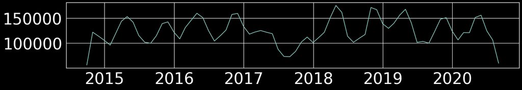

```python
import matplotlib.pyplot as plt
plt.rcParams["figure.figsize"] = (20,3)
plt.plot(df_date_index)
```

#### Testing For Stationarity

```python
### Testing For Stationarity

from statsmodels.tsa.stattools import adfuller

def adf_test(dataset):
  dftest = adfuller(dataset, autolag = 'AIC')
  print("1. ADF : ",dftest[0])
  print("2. P-Value : ", dftest[1])
  print("3. Num Of Lags : ", dftest[2])
  print("4. Num Of Observations Used For ADF Regression and Critical Values Calculation :", dftest[3])
  print("5. Critical Values :")
  for key, val in dftest[4].items():
      print("\t",key, ": ", val)
```

## AD-FULLER-TEST

```python
df_date_index.columns
```

```
Index(['Page_Loads'], dtype='object')
```

```python
adf_test(df_date_index['Page_Loads'])
```

```
1. ADF :  -2.410024672338927
2. P-Value :  0.13892698645568835
3. Num Of Lags :  12
4. Num Of Observations Used For ADF Regression and Critical Values Calculation : 59
5. Critical Values :
	 1% :  -3.5463945337644063
	 5% :  -2.911939409384601
	 10% :  -2.5936515282964665
```

### DIFFERENCING

```python
df_date_index['Page_Loads_First_Order_Differencing'] = df_date_index['Page_Loads'] - df_date_index['Page_Loads'].shift(1)
```

```python
adf_test(df_date_index['Page_Loads_First_Order_Differencing'].dropna())
```

```
1. ADF :  -1.9067763211534854
2. P-Value :  0.32888006117831814
3. Num Of Lags :  11
4. Num Of Observations Used For ADF Regression and Critical Values Calculation : 59
5. Critical Values :
	 1% :  -3.5463945337644063
	 5% :  -2.911939409384601
	 10% :  -2.5936515282964665
```

```python
df_date_index['Page_Loads_Second_Order_Differencing'] = df_date_index['Page_Loads_First_Order_Differencing'] - df_date_index['Page_Loads_First_Order_Differencing'].shift(1)
```

```python
adf_test(df_date_index['Page_Loads_Second_Order_Differencing'].dropna())
```

```
1. ADF :  -5.5736290225934155
2. P-Value :  1.4486118892546306e-06
3. Num Of Lags :  10
4. Num Of Observations Used For ADF Regression and Critical Values Calculation : 59
5. Critical Values :
	 1% :  -3.5463945337644063
	 5% :  -2.911939409384601
	 10% :  -2.5936515282964665
```

```python
def adfuller_test(confirmed):

    result=adfuller(confirmed)

    labels = ['ADF Test Statistic','p-value','#Lags Used','Number of Observations Used']

    for value,label in zip(result,labels):
        print(label+' : '+str(value) )

    if result[1] <= 0.05:

        print("strong evidence against the null hypothesis(Ho), reject the null hypothesis. Data has no unit root and is stationary")
    else:
        print("weak evidence against null hypothesis, time series has a unit root, indicating it is non-stationary ")
```

```python
adfuller_test(df_date_index['Page_Loads_Second_Order_Differencing'].dropna())
```

```
ADF Test Statistic : -5.5736290225934155
p-value : 1.4486118892546306e-06
#Lags Used : 10
Number of Observations Used : 59
strong evidence against the null hypothesis(Ho), reject the null hypothesis. Data has no unit root and is stationary
```

### Plotting ACF and PACF

###### Autocorrelation and Partial Autocorrelation Functions

• Autocorrelation is simply the correlation of a series with its own lags. If a series is significantly autocorrelated, that means, the previous values of the series (lags) may be helpful in predicting the current value.  
• Partial Autocorrelation also conveys similar information but it conveys the pure correlation of a series and its lag, excluding the correlation contributions from the intermediate lags.

```python
from statsmodels.graphics.tsaplots import plot_acf,plot_pacf
```

```python
df_date_index.columns
```

```
Index(['Page_Loads', 'Page_Loads_First_Order_Differencing',
       'Page_Loads_Second_Order_Differencing'],
      dtype='object')
```

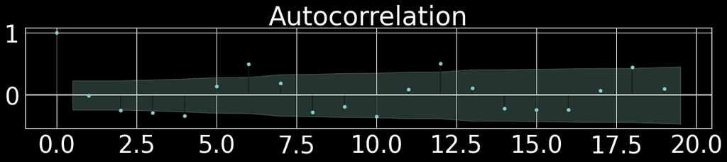

```python
acf2 = plot_acf(df_date_index['Page_Loads_Second_Order_Differencing'].dropna())
```

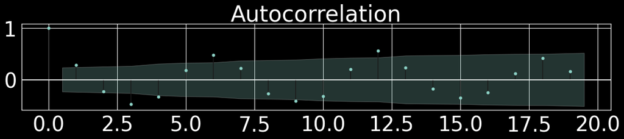

```python
acf1 = plot_acf(df_date_index["Page_Loads_First_Order_Differencing"].dropna())
```

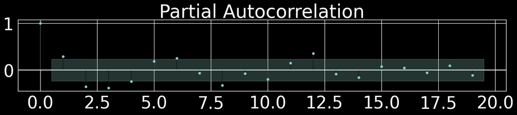

```python
result1 = plot_pacf(df_date_index["Page_Loads_First_Order_Differencing"].dropna())
```

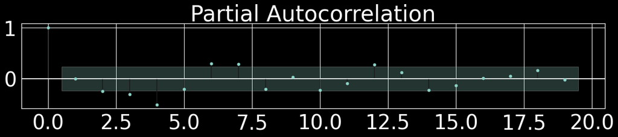

```python
result2 = plot_pacf(df_date_index['Page_Loads_Second_Order_Differencing'].dropna())
```

#### Split Data into `Training` and `Testing`

```python
print(df_date_index.shape)
train=df_date_index.iloc[:-30]
test=df_date_index.iloc[-30:]
print(train.shape,test.shape)
### print(test.iloc[0],test.iloc[-1])
```

```
(72, 3)
(42, 3) (30, 3)
```

```python
train.columns
```

```
Index(['Page_Loads', 'Page_Loads_First_Order_Differencing',
       'Page_Loads_Second_Order_Differencing'],
      dtype='object')
```

```python
from statsmodels.tsa.arima.model   import ARIMA
model_ARIMA=ARIMA(train['Page_Loads_Second_Order_Differencing'],order=(0,2,0))
```

```python
model_Arima_fit=model_ARIMA.fit()
```

```python
model_Arima_fit.summary()
```

SARIMAX Results

| Dep. Variable: | Page_Loads_Second_Order_Differencing | No. Observations: | 42 |
| --- | --- | --- | --- |
| Model: | ARIMA(0, 2, 0) | Log Likelihood | -483.086 |
| Date: | Sun, 11 Dec 2022 | AIC | 968.171 |
| Time: | 16:08:09 | BIC | 969.860 |
| Sample: | 09-30-2014 | HQIC | 968.782 |
|  | - 02-28-2018 |  |  |
| Covariance Type: | opg |  |  |

|  | coef | std err | z | P>\|z\| | [0.025 | 0.975] |
| --- | --- | --- | --- | --- | --- | --- |
| sigma2 | 1.381e+09 | 3.09e+08 | 4.465 | 0.000 | 7.75e+08 | 1.99e+09 |

| Ljung-Box (L1) (Q): | 13.79 | Jarque-Bera (JB): | 0.70 |
| --- | --- | --- | --- |
| Prob(Q): | 0.00 | Prob(JB): | 0.70 |
| Heteroskedasticity (H): | 0.87 | Skew: | -0.06 |
| Prob(H) (two-sided): | 0.80 | Kurtosis: | 2.36 |

Warnings:  
[1] Covariance matrix calculated using the outer product of gradients (complex-step).

```python
##prediction
pred_start_date=test.index[0]
pred_end_date=test.index[-1]
print(pred_start_date)
print(pred_end_date)
```

```
2018-03-31 00:00:00
2020-08-31 00:00:00
```

```python
pred=model_Arima_fit.predict(start=pred_start_date,end=pred_end_date)
```

```python
residuals=test['Page_Loads']- pred
```

```python
residuals.head(3)
```

```
Date
2018-03-31    173775.0
2018-04-30    220193.0
2018-05-31    228379.0
dtype: float64
```

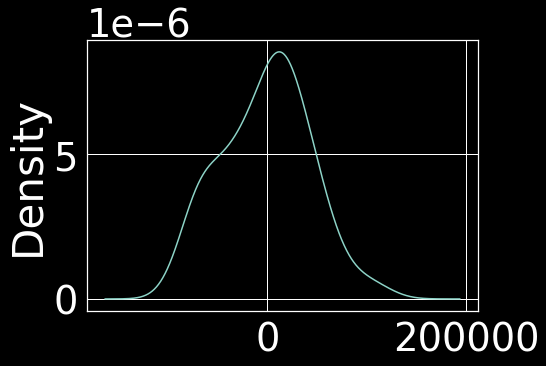

```python
plt.figure(figsize=[7,5])
model_Arima_fit.resid.plot(kind='kde')
plt.show()
```

```python
test['Predicted_ARIMA']=pred
```

```python
test.columns
```

```
Index(['Page_Loads', 'Page_Loads_First_Order_Differencing',
       'Page_Loads_Second_Order_Differencing', 'Predicted_ARIMA'],
      dtype='object')
```

```python
from sklearn.metrics import mean_squared_error, r2_score, mean_absolute_error, median_absolute_error, mean_squared_log_error
```

```python
from math import sqrt
```

```python
# report performance
mse = mean_squared_error(test["Page_Loads"], test["Predicted_ARIMA"])
rmse = sqrt(mse)
print('ARIMA RMSE: {}, MSE:{}'.format(rmse,mse))

##plt.title('RMSE: %.4f'% rmse)
```

```
ARIMA RMSE: 507774.5966582679, MSE:257835041011.46667
```

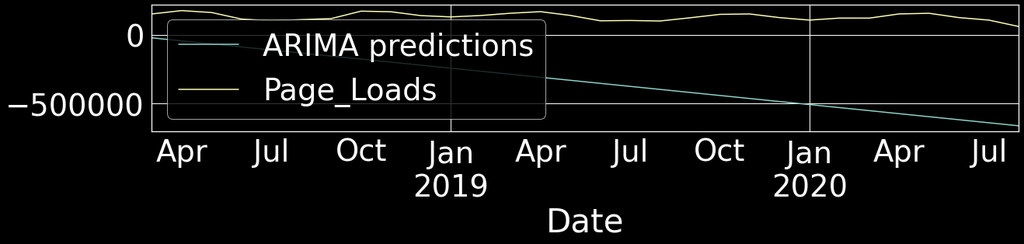

```python
start=len(train)
end=len(train)+len(test)-1
#if the predicted values dont have date values as index, you will have to uncomment the following two commented lines to plot a graph
#index_future_dates=pd.date_range(start='2018-12-01',end='2018-12-30')
pred=model_Arima_fit.predict(start=start,end=end,typ='levels').rename('ARIMA predictions')
#pred.index=index_future_dates
pred.plot(legend=True)
test['Page_Loads'].plot(legend=True)
```

```python
df2.columns
```

```
Index(['Page.Loads', 'Unique.Visits', 'First.Time.Visits', 'Returning.Visits'], dtype='object')
```

```python
df2.head(3)
```

| Date | Page.Loads | Unique.Visits | First.Time.Visits | Returning.Visits |
| --- | --- | --- | --- | --- |
| 2014-09-14 | 2146 | 1582 | 1430 | 152 |
| 2014-09-15 | 3621 | 2528 | 2297 | 231 |
| 2014-09-16 | 3698 | 2630 | 2352 | 278 |

```python
df2 = df2.reset_index()
```

```python
df2.head(3)
```

|  | Date | Page.Loads | Unique.Visits | First.Time.Visits | Returning.Visits |
| --- | --- | --- | --- | --- | --- |
| 0 | 2014-09-14 | 2146 | 1582 | 1430 | 152 |
| 1 | 2014-09-15 | 3621 | 2528 | 2297 | 231 |
| 2 | 2014-09-16 | 3698 | 2630 | 2352 | 278 |

```python
final = df2[["Date","Page.Loads"]]
```

```python
final.columns
```

```
Index(['Date', 'Page.Loads'], dtype='object')
```

```python
y = pd.Series(data=final['Page.Loads'].values, index=final['Date'])
```

```python
y.head(3)
```

```
Date
2014-09-14    2146
2014-09-15    3621
2014-09-16    3698
dtype: int64
```